# Taller de R — Nupcialidad y exposición al riesgo de embarazo en Colombia

Análisis reproducible con datos agregados de la ENDS 2025 (Capítulo 5)

Dinámica Poblacional y Demografía

17 de September de 2026

# 1 Presentación del taller

Este taller reconstruye, paso a paso y con código fácilmente ejecutable, los principales indicadores de **nupcialidad y exposición al riesgo de embarazo** que publica el Capítulo 5 de la **Encuesta Nacional de Demografía y Salud (ENDS) 2025** del Ministerio de Salud y Protección Social de Colombia.

**Fuente de los datos:** Minsalud (2025). *Nupcialidad y exposición al riesgo de embarazo* (Cap. 5, ENDS 2025). https://www.minsalud.gov.co/sites/rid/Lists/BibliotecaDigital/RIDE/VS/ED/GCFI/publicacion-nupcialidad-ends-2025.pdf

## 1.1 Nota metodológica importante (léala antes de correr el código)

La ENDS 2025 se procesa a partir de **microdatos** con **factores de expansión** (el propio Ministerio informa que sus tablas se calcularon en R con esos factores). La publicación en PDF, sin embargo, entrega los resultados **ya agregados y expandidos**. Por eso en este taller **no reestimamos** desde microdatos: cargamos las cifras oficiales como `tibbles` y practicamos el flujo de **manipulación, agregación y visualización** con `tidyverse` y `ggplot2`.

> **Distinción pedagógica.** Con microdatos reales de la ENDS el flujo correcto sería declarar el diseño muestral (`survey` / `srvyr`), por ejemplo `as_survey_design(weights = factor_expansion, strata = ..., ids = ...)`, y recién ahí calcular proporciones y medianas. Aquí trabajamos sobre agregados publicados, que es un escenario frecuente y perfectamente válido para análisis secundario.

## 1.2 Paquetes

```r
# install.packages(c("tidyverse", "scales"))  # ejecutar una sola vez si hace falta
library(tidyverse)
library(scales)

# Tema común para todas las figuras del taller
theme_taller <- theme_minimal(base_size = 12) +
  theme(
    plot.title    = element_text(face = "bold"),
    plot.subtitle = element_text(color = "grey30"),
    panel.grid.minor = element_blank(),
    legend.position  = "top",
    legend.title     = element_blank()
  )
theme_set(theme_taller)

# Paleta reutilizable
pal <- c("#1b6ca8", "#f28e2b", "#59a14f", "#e15759", "#b07aa1")
```

# 2 El inicio de la exposición: primera relación sexual

La edad de la primera relación sexual marca el **inicio de la exposición al riesgo de embarazo**. Dos hechos son centrales en la ENDS 2025.

## 2.1 Tendencia intergeneracional (ENDS 1990–2025)

Porcentaje de mujeres de 20 a 24 años que tuvo su primera relación sexual **antes de los 18 años**, comparando todas las rondas de la ENDS (Gráfico 5.2).

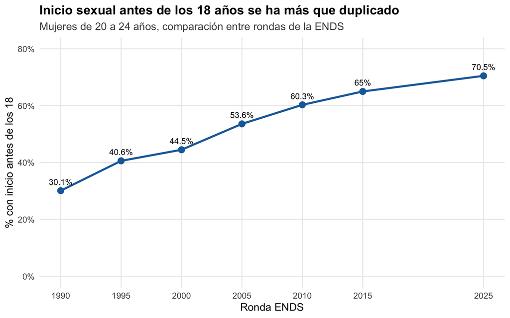

```r
inicio_tendencia <- tibble(
  ends = c(1990, 1995, 2000, 2005, 2010, 2015, 2025),
  pct  = c(30.1, 40.6, 44.5, 53.6, 60.3, 65.0, 70.5)
)

ggplot(inicio_tendencia, aes(ends, pct)) +
  geom_line(color = pal[1], linewidth = 1.1) +
  geom_point(color = pal[1], size = 3) +
  geom_text(aes(label = paste0(pct, "%")), vjust = -1, size = 3.3) +
  scale_x_continuous(breaks = inicio_tendencia$ends) +
  scale_y_continuous(labels = label_percent(scale = 1), limits = c(0, 80)) +
  labs(
    title = "Inicio sexual antes de los 18 años se ha más que duplicado",
    subtitle = "Mujeres de 20 a 24 años, comparación entre rondas de la ENDS",
    x = "Ronda ENDS", y = "% con inicio antes de los 18"
  )
```

**Lectura.** El indicador pasó de **30,1 % (1990) a 70,5 % (2025)**: las cohortes más jóvenes inician su vida sexual —y por tanto su exposición— cada vez más temprano.

## 2.2 Efecto de cohorte dentro de la ENDS 2025

Dentro de una misma encuesta, las mujeres más jóvenes reportan inicios más tempranos. Usamos el % que tuvo relaciones **antes de los 15 años** y la **edad mediana** de la primera relación por grupo de edad actual (Tabla 5.3, total urbano + rural).

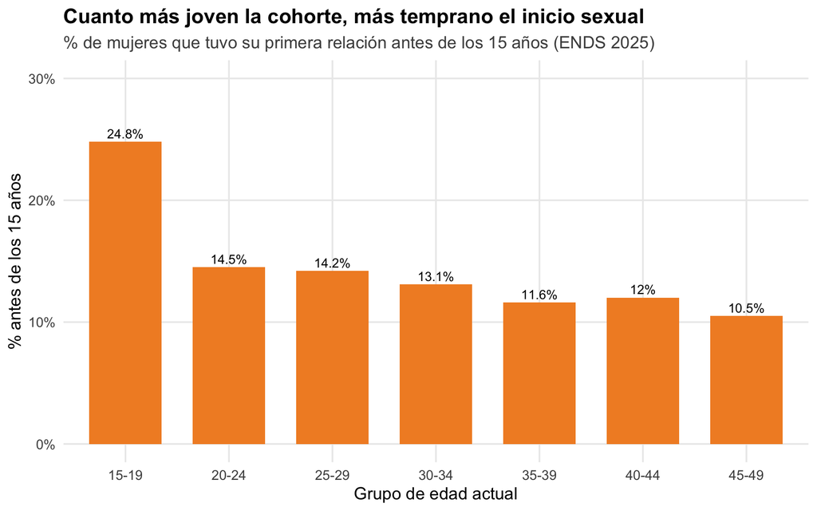

```r
niveles_edad <- c("15-19","20-24","25-29","30-34","35-39","40-44","45-49")

inicio_cohorte <- tibble(
  grupo_edad = factor(niveles_edad, levels = niveles_edad),
  antes_15   = c(24.8, 14.5, 14.2, 13.1, 11.6, 12.0, 10.5),
  mediana    = c(15,   16,   16,   17,   17,   17,   17)
)

ggplot(inicio_cohorte, aes(grupo_edad, antes_15)) +
  geom_col(fill = pal[2], width = 0.7) +
  geom_text(aes(label = paste0(antes_15, "%")), vjust = -0.4, size = 3.2) +
  scale_y_continuous(labels = label_percent(scale = 1), limits = c(0, 30)) +
  labs(
    title = "Cuanto más joven la cohorte, más temprano el inicio sexual",
    subtitle = "% de mujeres que tuvo su primera relación antes de los 15 años (ENDS 2025)",
    x = "Grupo de edad actual", y = "% antes de los 15 años"
  )
```

```r
inicio_cohorte   # la edad mediana baja de 17 a 15 años entre las más jóvenes
```

| grupo_edad | antes_15 | mediana |
| --- | --- | --- |
| 15-19 | 24.8 | 15 |
| 20-24 | 14.5 | 16 |
| 25-29 | 14.2 | 16 |
| 30-34 | 13.1 | 17 |
| 35-39 | 11.6 | 17 |
| 40-44 | 12.0 | 17 |
| 45-49 | 10.5 | 17 |

# 3 Estado conyugal y Segunda Transición Demográfica

## 3.1 Distribución por grupo de edad (mujeres 13–49)

Reconstruimos la Tabla 5.12 (total nacional) y la graficamos como barras apiladas al 100 %. El estado conyugal es un determinante directo de la exposición: la unión concentra la mayor frecuencia de relaciones sexuales recientes.

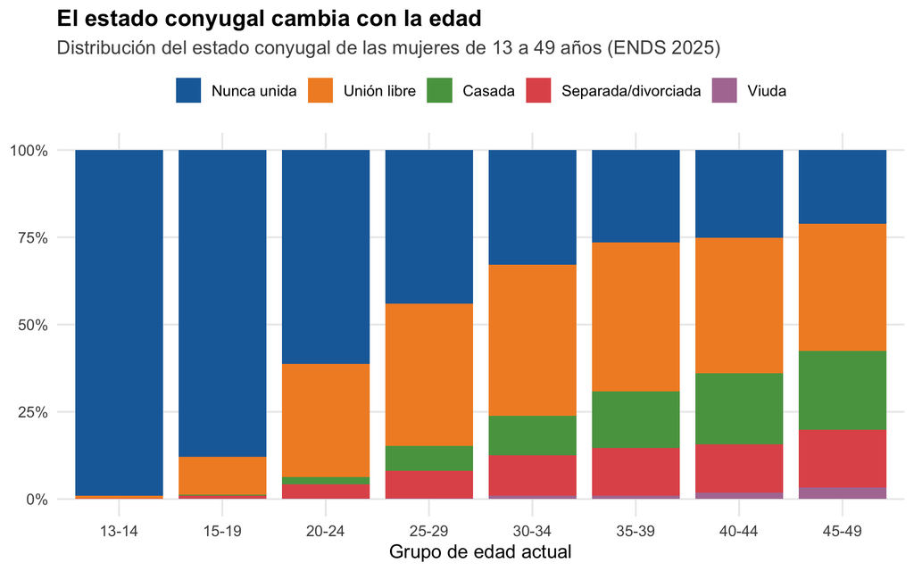

```r
niveles_edad2 <- c("13-14", niveles_edad)

conyugal_edad <- tribble(
  ~grupo_edad, ~`Nunca unida`, ~Casada, ~`Unión libre`, ~`Separada/divorciada`, ~Viuda,
  "13-14", 99.0, 0.0,  0.9,  0.1, 0.0,
  "15-19", 88.0, 0.2, 10.9,  0.9, 0.1,
  "20-24", 61.3, 2.1, 32.4,  4.1, 0.1,
  "25-29", 44.0, 7.1, 40.8,  7.9, 0.2,
  "30-34", 32.8, 11.4, 43.3, 11.6, 0.9,
  "35-39", 26.5, 16.3, 42.7, 13.6, 1.0,
  "40-44", 25.2, 20.4, 38.7, 13.9, 1.8,
  "45-49", 21.1, 22.6, 36.4, 16.6, 3.3
)

orden_estado <- c("Nunca unida","Unión libre","Casada","Separada/divorciada","Viuda")

conyugal_largo <- conyugal_edad %>%
  pivot_longer(-grupo_edad, names_to = "estado", values_to = "pct") %>%
  mutate(
    grupo_edad = factor(grupo_edad, levels = niveles_edad2),
    estado     = factor(estado, levels = orden_estado)
  )

ggplot(conyugal_largo, aes(grupo_edad, pct, fill = estado)) +
  geom_col(position = "fill", width = 0.85) +
  scale_y_continuous(labels = label_percent()) +
  scale_fill_manual(values = pal) +
  labs(
    title = "El estado conyugal cambia con la edad",
    subtitle = "Distribución del estado conyugal de las mujeres de 13 a 49 años (ENDS 2025)",
    x = "Grupo de edad actual", y = NULL
  )
```

**Lectura.** La **unión libre** supera al **matrimonio** en todos los grupos de edad: es la forma predominante de unión en Colombia.

## 3.2 Tendencia temporal (2010–2015–2025)

Comparación entre rondas para tres estados clave (texto del apartado 5.4.2.1). El dato de “nunca unida” en 2010 no fue reportado, por lo que queda como `NA`.

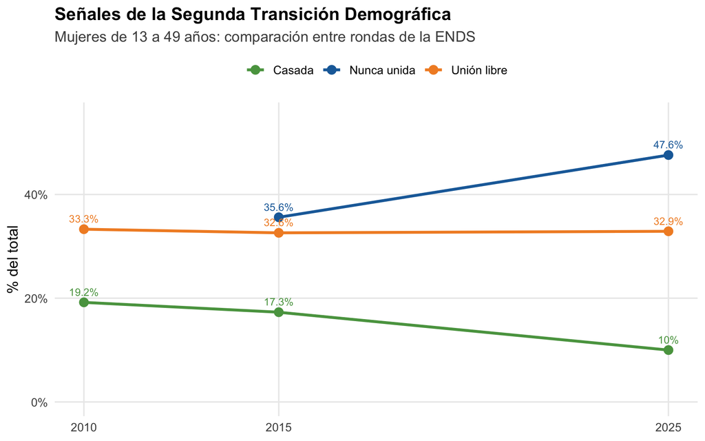

```r
conyugal_tendencia <- tribble(
  ~anio, ~estado,        ~pct,
  2010,  "Casada",       19.2,
  2015,  "Casada",       17.3,
  2025,  "Casada",       10.0,
  2010,  "Unión libre",  33.3,
  2015,  "Unión libre",  32.6,
  2025,  "Unión libre",  32.9,
  2015,  "Nunca unida",  35.6,
  2025,  "Nunca unida",  47.6
)

ggplot(conyugal_tendencia, aes(anio, pct, color = estado)) +
  geom_line(linewidth = 1.1, na.rm = TRUE) +
  geom_point(size = 3) +
  geom_text(aes(label = paste0(pct, "%")), vjust = -0.9, size = 3, show.legend = FALSE) +
  scale_x_continuous(breaks = c(2010, 2015, 2025)) +
  scale_y_continuous(labels = label_percent(scale = 1), limits = c(0, 55)) +
  scale_color_manual(values = pal[c(3,1,2)]) +
  labs(
    title = "Señales de la Segunda Transición Demográfica",
    subtitle = "Mujeres de 13 a 49 años: comparación entre rondas de la ENDS",
    x = NULL, y = "% del total"
  )
```

**Lectura.** Sube “nunca unida” (35,6 % → 47,6 %), cae con fuerza el matrimonio (19,2 % → 10,0 %) y la unión libre se mantiene estable y alta: menos institución formal, más consensualidad y postergación de la unión (Flórez y Sánchez, 2013).

# 4 Edad a la primera unión: gradientes socioeconómicos de la exposición

La ENDS lo dice explícitamente: *“entre más joven sea la pareja en el momento de la unión, especialmente la mujer, mayor será el tiempo de exposición al riesgo de embarazo”*. La edad promedio nacional a la primera unión de las mujeres es **21,3 años**. Veamos cómo varía.

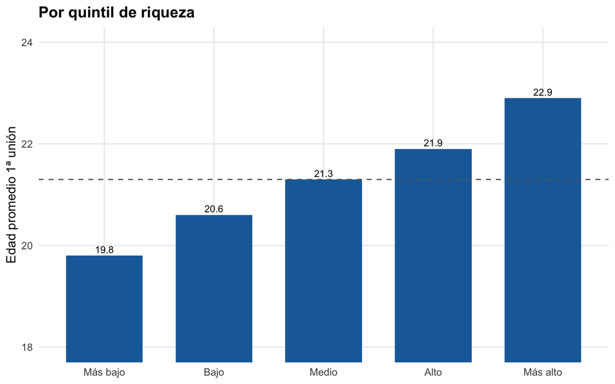

```r
nac_union <- 21.3  # promedio nacional (Tabla 5.18)

# Por quintil de riqueza
union_quintil <- tibble(
  quintil = factor(c("Más bajo","Bajo","Medio","Alto","Más alto"),
                   levels = c("Más bajo","Bajo","Medio","Alto","Más alto")),
  edad    = c(19.8, 20.6, 21.3, 21.9, 22.9)
)

# Por nivel educativo
union_educ <- tibble(
  nivel = factor(c("Sin educación","Primaria","Secundaria","Superior"),
                 levels = c("Sin educación","Primaria","Secundaria","Superior")),
  edad  = c(20.3, 20.6, 20.6, 22.8)
)

p_quintil <- ggplot(union_quintil, aes(quintil, edad)) +
  geom_col(fill = pal[1], width = 0.7) +
  geom_hline(yintercept = nac_union, linetype = "dashed", color = "grey40") +
  geom_text(aes(label = edad), vjust = -0.4, size = 3.2) +
  coord_cartesian(ylim = c(18, 24)) +
  labs(title = "Por quintil de riqueza", x = NULL, y = "Edad promedio 1ª unión")

p_educ <- ggplot(union_educ, aes(nivel, edad)) +
  geom_col(fill = pal[3], width = 0.7) +
  geom_hline(yintercept = nac_union, linetype = "dashed", color = "grey40") +
  geom_text(aes(label = edad), vjust = -0.4, size = 3.2) +
  coord_cartesian(ylim = c(18, 24)) +
  labs(title = "Por nivel educativo", x = NULL, y = NULL)

p_quintil  # línea discontinua = promedio nacional (21,3)
```

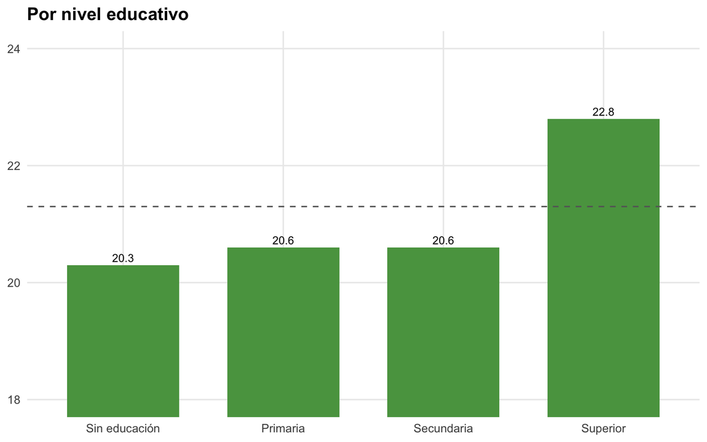

```r
p_educ
```

**Lectura.** A mayor quintil de riqueza y mayor nivel educativo, **más tardía** la primera unión (del quintil más bajo, 19,8, al más alto, 22,9; de secundaria, 20,6, a superior, 22,8). La postergación reduce el tiempo de exposición en edades jóvenes.

# 5 Diferencia de edad con la primera pareja: asimetrías de poder

La brecha de edad con la primera pareja conyugal es un **indicador de asimetría de poder** (negociación sobre sexualidad, anticoncepción y economía del hogar). Reconstruimos la Tabla 5.20 (mujeres alguna vez unidas).

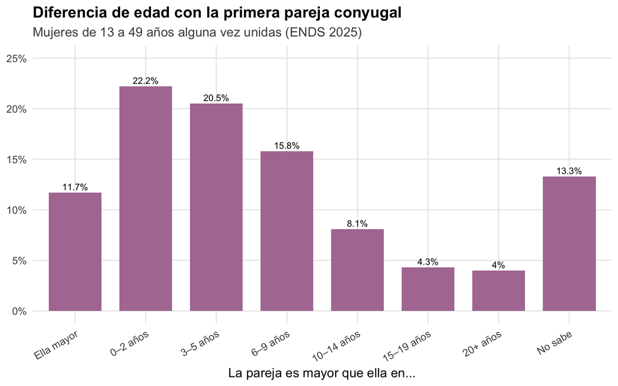

```r
niveles_dif <- c("Ella mayor","0–2 años","3–5 años","6–9 años",
                 "10–14 años","15–19 años","20+ años","No sabe")

dif_edad <- tibble(
  categoria = factor(niveles_dif, levels = niveles_dif),
  urbana    = c(12.4, 22.8, 21.4, 15.5, 7.7, 3.3, 3.9, 13.0),
  rural     = c( 9.2, 19.8, 16.9, 17.1, 9.8, 8.1, 4.7, 14.4),
  nacional  = c(11.7, 22.2, 20.5, 15.8, 8.1, 4.3, 4.0, 13.3)
)

# Distribución nacional
ggplot(dif_edad, aes(categoria, nacional)) +
  geom_col(fill = pal[5], width = 0.75) +
  geom_text(aes(label = paste0(nacional, "%")), vjust = -0.4, size = 3) +
  scale_y_continuous(labels = label_percent(scale = 1), limits = c(0, 25)) +
  labs(
    title = "Diferencia de edad con la primera pareja conyugal",
    subtitle = "Mujeres de 13 a 49 años alguna vez unidas (ENDS 2025)",
    x = "La pareja es mayor que ella en...", y = NULL
  ) +
  theme(axis.text.x = element_text(angle = 30, hjust = 1))
```

Ahora **derivamos un indicador compuesto**: proporción de mujeres cuya primera pareja era **al menos 10 años mayor**, comparando zona urbana y rural.

```r
brecha_10 <- dif_edad %>%
  filter(categoria %in% c("10–14 años","15–19 años","20+ años")) %>%
  summarise(
    Urbana   = sum(urbana),
    Rural    = sum(rural),
    Nacional = sum(nacional)
  ) %>%
  pivot_longer(everything(), names_to = "zona", values_to = "pct") %>%
  mutate(zona = factor(zona, levels = c("Urbana","Nacional","Rural")))

brecha_10
```

| zona | pct |
| --- | --- |
| Urbana | 14.9 |
| Rural | 22.6 |
| Nacional | 16.4 |

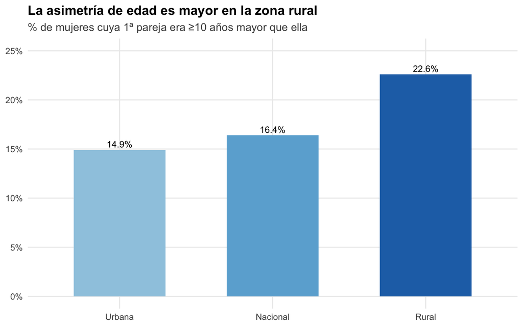

```r
ggplot(brecha_10, aes(zona, pct, fill = zona)) +
  geom_col(width = 0.6, show.legend = FALSE) +
  geom_text(aes(label = paste0(round(pct, 1), "%")), vjust = -0.4, size = 3.5) +
  scale_y_continuous(labels = label_percent(scale = 1), limits = c(0, 25)) +
  scale_fill_manual(values = c("#9ecae1", "#6baed6", "#2171b5")) +
  labs(
    title = "La asimetría de edad es mayor en la zona rural",
    subtitle = "% de mujeres cuya 1ª pareja era ≥10 años mayor que ella",
    x = NULL, y = NULL
  )
```

**Lectura.** A nivel nacional **1 de cada 6 mujeres (16,4 %)** se unió con una pareja al menos 10 años mayor; en la zona **rural la cifra sube a 22,6 %** frente a **14,9 %** urbana. Mayor brecha de edad ⇒ mayor asimetría de poder en la relación.

# 6 Uniones tempranas y matrimonio infantil (MIUT)

La ENDS 2025 incorpora el monitoreo del **matrimonio infantil y las uniones tempranas (MIUT)** tras la **Ley 2447 de 2025**, que prohíbe estas prácticas. El dato de referencia (Anexo 5.1): quiénes se unieron **antes de los 18 años**.

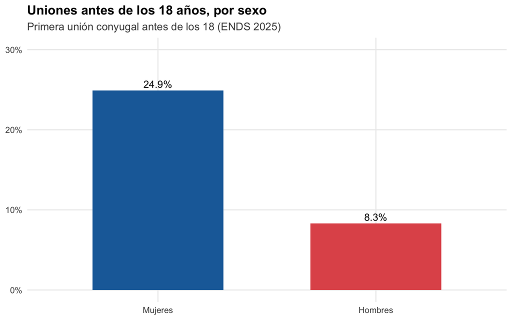

```r
union_temprana <- tibble(
  sexo     = c("Mujeres", "Hombres"),
  antes_18 = c(24.9, 8.3)
)

ggplot(union_temprana, aes(reorder(sexo, -antes_18), antes_18, fill = sexo)) +
  geom_col(width = 0.6, show.legend = FALSE) +
  geom_text(aes(label = paste0(antes_18, "%")), vjust = -0.4, size = 4) +
  scale_y_continuous(labels = label_percent(scale = 1), limits = c(0, 30)) +
  scale_fill_manual(values = pal[c(4,1)]) +
  labs(
    title = "Uniones antes de los 18 años, por sexo",
    subtitle = "Primera unión conyugal antes de los 18 (ENDS 2025)",
    x = NULL, y = NULL
  )
```

**Lectura.** **Casi 1 de cada 4 mujeres (24,9 %)** frente a **8,3 % de los hombres** se unió antes de los 18: la unión temprana es un fenómeno fuertemente feminizado, con implicaciones directas en embarazo adolescente, deserción escolar y salud materna.

# 7 Síntesis: la ventana de exposición por quintil de riqueza

Cerramos integrando dos hitos del ciclo reproductivo —**inicio sexual** y **primera unión**— para visualizar cómo se **abre más temprano la ventana de exposición** en los quintiles de menor riqueza.

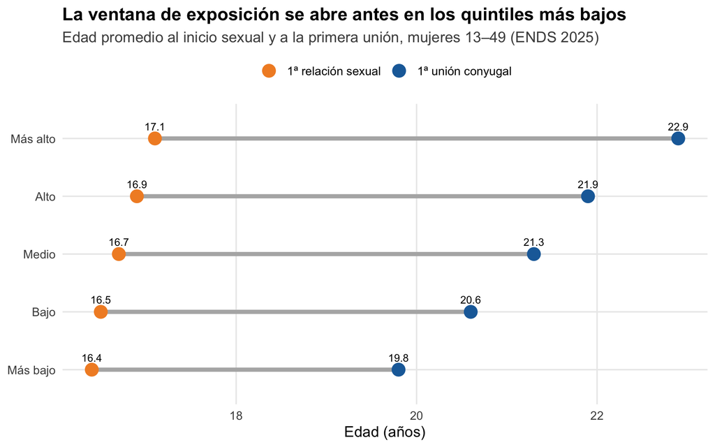

```r
exposicion_quintil <- tibble(
  quintil = factor(c("Más bajo","Bajo","Medio","Alto","Más alto"),
                   levels = c("Más bajo","Bajo","Medio","Alto","Más alto")),
  `1ª relación sexual` = c(16.4, 16.5, 16.7, 16.9, 17.1),  # Tabla 5.5
  `1ª unión conyugal`  = c(19.8, 20.6, 21.3, 21.9, 22.9)   # Tabla 5.18
)

exp_largo <- exposicion_quintil %>%
  pivot_longer(-quintil, names_to = "hito", values_to = "edad")

ggplot() +
  geom_segment(
    data = exposicion_quintil,
    aes(x = `1ª relación sexual`, xend = `1ª unión conyugal`,
        y = quintil, yend = quintil),
    color = "grey70", linewidth = 1.6
  ) +
  geom_point(data = exp_largo, aes(edad, quintil, color = hito), size = 4.5) +
  geom_text(data = exp_largo, aes(edad, quintil, label = edad),
            vjust = -1.1, size = 3, show.legend = FALSE) +
  scale_color_manual(values = pal[c(2,1)]) +
  labs(
    title = "La ventana de exposición se abre antes en los quintiles más bajos",
    subtitle = "Edad promedio al inicio sexual y a la primera unión, mujeres 13–49 (ENDS 2025)",
    x = "Edad (años)", y = NULL
  )
```

Podemos cuantificar el **rezago entre inicio sexual y unión** (una aproximación al período de exposición previo a la unión) por quintil:

```r
exposicion_quintil %>%
  mutate(`Rezago (años)` = round(`1ª unión conyugal` - `1ª relación sexual`, 1)) %>%
  arrange(quintil)
```

| quintil | 1ª relación sexual | 1ª unión conyugal | Rezago (años) |
| --- | --- | --- | --- |
| Más bajo | 16.4 | 19.8 | 3.4 |
| Bajo | 16.5 | 20.6 | 4.1 |
| Medio | 16.7 | 21.3 | 4.6 |
| Alto | 16.9 | 21.9 | 5.0 |
| Más alto | 17.1 | 22.9 | 5.8 |

**Síntesis general.** Los quintiles más pobres combinan **inicio sexual más temprano** y **unión más temprana**: la exposición al riesgo de embarazo comienza antes y se concentra en edades más jóvenes. El gradiente educativo y de riqueza, la brecha de edad con la pareja (mayor en zonas rurales) y la persistencia de uniones tempranas femeninas dibujan un mapa de **desigualdades estructurales** en salud sexual y reproductiva, coherente con el enfoque de determinantes sociales que adopta la ENDS.

# 8 Ejercicios propuestos

1. **Replique para hombres.** Reconstruya la Tabla 5.4 (inicio sexual masculino, edad mediana por grupo de edad) y compare las medianas con las de las mujeres en un mismo gráfico. ¿Se confirma que los hombres inician antes?
2. **Añada la dimensión regional.** Incorpore la columna 13–49 de la Tabla 5.18 por región (Atlántica, Oriental, Central, Bogotá, Pacífica, Orinoquía-Amazonía) y ordene las regiones por edad a la primera unión con `forcats::fct_reorder()`.
3. **Indicador de asimetría.** Generalice el indicador “pareja ≥10 años mayor” a las subregiones de la Tabla 5.20 y proponga un pequeño ranking de asimetría de poder.
4. **Número de uniones.** Con la Tabla 5.22, grafique el % de mujeres con 2 y con 3+ uniones por grupo de edad y discuta la relación con la Segunda Transición Demográfica.

# 9 Referencia

Ministerio de Salud y Protección Social (2025). *Nupcialidad y exposición al riesgo de embarazo*. Capítulo 5, Encuesta Nacional de Demografía y Salud (ENDS) 2025. Recuperado de la Biblioteca Digital del Minsalud.